# 🏔️ Hiking Trip Postcard Generator

This project will introduce you to many new ideas and concepts, while building something **fun**, **useful**, and **graphical** that you can customize and share.

You'll see how different pieces of technology come together — working with **text**, **images**, **data**, and **documents** — to create a **hiking trip postcard**.

Throughout the project, you will be introduced to the following areas:

## 📚 Working with Imports, Libraries, SDKs, and APIs

You'll learn how to **import and use external libraries** in your Python project.  
Instead of writing everything from scratch, we use powerful libraries that connect to external services (APIs) like OpenAI and OpenWeatherMap.  
This mirrors how real-world applications are built — by **leveraging existing tools** to create complex things quickly and efficiently.

**Example libraries you'll work with:**

- `openai` — Communicate with large language models and generate AI-powered content and images
- `requests` — Fetch data from web APIs (like weather information)
- `gspread` — Connect to Google Sheets to pull structured data easily

## 🖼️ Working with Images

You'll work with images in a very practical way — downloading, manipulating, cropping, converting to greyscale, and inserting them into documents.  
We use the **Pillow (`PIL`) library** to process images dynamically, without needing manual editing.  
You'll see how professional applications generate and adapt images automatically for different layouts and styles.

## 🎨 Generating Artwork with DALL-E

To create a stunning background for your postcards, you'll integrate **DALL-E** via the OpenAI API.  
DALL-E is an AI model that generates **unique, beautiful images** based on natural language prompts.  
You'll learn how to craft effective prompts, fetch the generated artwork, and fit it perfectly into your document design.  
This introduces you to the power of **AI-driven creative tools** that are revolutionizing art and media today.

## 📄 Working with PDFs

You'll create a **multi-page PDF** using **`fpdf2`**, one of the most popular Python libraries for document generation.  
This allows you to design layouts, add text, position images, and structure output exactly the way you want it.  
You'll learn how careful control over page size, margins, fonts, and backgrounds creates a polished final product ready to print or share.

## 🧠 Working with LLMs (Large Language Models)

You'll integrate **OpenAI's GPT-4** to **generate invitation texts automatically**, based on simple prompts you provide.  
This shows you how AI can be used not just for chatting — but for **content creation**, **automation**, and **custom applications** that feel personal, intelligent, and useful.

## 📈 Creating Data Visualizations

You'll collect information about hiking checkpoints (like distance and elevation) and **create beautiful elevation profile charts** using **`matplotlib`**.  
You'll learn how to structure your data, process it, and turn it into visuals that are easy to understand — a key skill for almost any modern software or data project.  
Additionally, you'll style the visualizations carefully, making them fit seamlessly into your final postcard design.

# 🚀 What Makes This Project Special?

```python
# Install required libraries
!pip install openai pillow fpdf2 requests matplotlib
```

[output not shown]

## Setup Open API

1. Create an OpenAI Account
- Go to platform.openai.com/signup
- Create a free account (email + password or Google login)
- Verify your email address
2. Get Your API Key
- Log in at [platform.openai.com](https://platform.openai.com/)
- Go to Personal → API Keys page
- Click Create New Secret Key
- Copy the API Key

Important:

- You can only copy it once — save it safely!
- If you lose it, you must generate a new key.
- API Key looks like: sk-xxxxxxxxxxxxxxxxxxxx

```python
import openai
import requests
from io import BytesIO
from PIL import Image, ImageEnhance
from fpdf import FPDF
import matplotlib.pyplot as plt

# --- Configuration ---
openai_api_key = 'YOUR_API_KEY'  # Replace with your OpenAI API Key
```

```python
# --- Step 1: Collect trip information ---
# We can use input prompts to collect trip information from the user.
trip_name = input("Enter the trip name: ")
date = input("Enter the date (e.g., June 10th, 2025): ")
location = input("Enter the location: ")
invitee = input("Enter the invitee's name: ")

# Or we can use predefined values for testing
address_lines = [
    "Invited Person",
    "Street Name",
    "PostCode City",
    "Country"
]

# The data format used here is a list of tuples, where each tuple contains:
# (name, total distance, elevation)
hike_points = [
    ("Trailhead", 0, 900),
    ("First lookout", 2, 1200),
    ("Waterfall", 4, 1300),
    ("Summit", 7, 1800),
    ("Lunch spot", 8, 1700),
    ("Final descent", 10, 1200),
    ("Trailhead", 14, 900)
]
```

```python
# --- Step 2: Generate invitation text ---
prompt = (
    f"Write a fun and friendly but short hiking trip invitation for '{invitee}' titled '{trip_name}' happening on {date} at {location}. "
    f"Only produce the invitation text, no other information and no subject, sign the invitation with YOUR NAME."
)

# Configure the client
client = openai.OpenAI(api_key=openapi_api_key)

# Generate text
response = client.chat.completions.create(
    model="gpt-4",
    messages=[
        {"role": "user", "content": prompt}
    ]
)

invitation_text = response.choices[0].message.content

print("\nGenerated Invitation:\n", invitation_text)
```

```
Generated Invitation:
 Hey Ella!

Warm greetings to you! Does your calendar look as empty as a deserted hiking trail on May 1st, 2025? If so, let's change that!

I'm inviting you to escape the bustling city and join me for a weekend getaway at Magdalensberg. Lace-up your favorite pair of hiking boots, pack a bag, bring your cheerful spirit, and let's explore the picturesque landscapes, serene environment and cherish the fantastic outdoor moments.

You are personally needed to help make this trip not just good, but great! I know you're quite the adventurer, and I believe this hike will quench your thirst for a thrilling expedition.

Looking forward to a weekend of breath-taking views, unique fauna, and unforgettable conversations.

Let's go campfires and chill!

Cheers,
Elias.
```

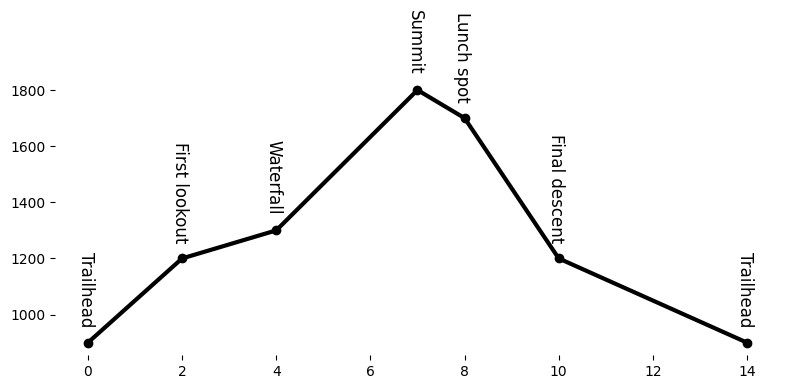

```python
# --- Step 3: Generate a graph of the hike ---
# Split into three lists
names = [point[0] for point in hike_points]
distances = [point[1] for point in hike_points]
elevations = [point[2] for point in hike_points]

# Create a figure
fig, ax = plt.subplots(figsize=(8,4))

# Plot elevation profile with thicker line
ax.plot(distances, elevations, marker='o', linewidth=3, color='black')

# Annotate points with their names, angled
for i, name in enumerate(names):
    ax.text(distances[i]-0.05, elevations[i]+70, name, ha='center', rotation=-90, fontsize=12)

# Remove the spines for cleaner look
ax.spines['left'].set_visible(False)
ax.spines['bottom'].set_visible(False)
ax.spines['top'].set_visible(False)
ax.spines['right'].set_visible(False)

# Option: create a Light grid
# ax.grid(True, which='both', linestyle='--', linewidth=0.5, color="black")

plt.tight_layout()
plt.savefig("hike_elevation_profile.png", transparent=True)  # Save with transparent background
plt.show()
```

```python
# --- Step 3: Generate a background image with DALL-E ---
image_prompt = f"A breathtaking mountain landscape in the style of a Studio Ghibli movie, soft watercolor textures, lush green meadows, vibrant wildflowers, misty peaks in the distance, bright blue sky with fluffy white clouds, warm magical lighting, peaceful and adventurous atmosphere, anime-style detailed environment, highly detailed, concept art"

image_response = client.images.generate(
    model="dall-e-3",
    prompt=image_prompt,
    n=1,
    size="1792x1024" # Possible sizes: 1024x1024, 1792x1024, 1024x1792
)

# Save the image to the current directory as a JPEG
image_url = image_response.data[0].url
image_data = requests.get(image_url).content
background = Image.open(BytesIO(image_data)).convert("RGB")
background.save("background.jpg")
```

```python
# --- Step 4: Prepare the image for the postcard ---
def crop_center(image_path, target_path):
    image = Image.open(image_path)
    target_ratio = 148 / 105  # Width / Height

    # Resize to postcard final size
    width, height = image.size
    img_ratio = width / height

    if img_ratio > target_ratio:
        # Image is too wide → crop width
        new_width = int(height * target_ratio)
        left = (width - new_width) // 2
        box = (left, 0, left + new_width, height)
    else:
        # Image is too tall → crop height
        new_height = int(width / target_ratio)
        top = (height - new_height) // 2
        box = (0, top, width, top + new_height)

    cropped_image = image.crop(box)
    cropped_image = cropped_image.resize((1480, 1050))
    cropped_image.save(target_path)

def to_greyscale(image_path, output_path):
    # Open image and convert to grayscale
    image = Image.open(image_path).convert("L")

    # Save the grayscale image
    image.save(output_path)

def dim_image(image_path, output_path, opacity=0.5):
    # Open image and convert to RGBA
    image = Image.open(image_path).convert("RGBA")

    # Create a black image the same size
    black_overlay = Image.new("RGBA", image.size, (255, 255, 255, int(255 * (1 - opacity))))

    # Composite the black overlay on top
    dimmed_image = Image.alpha_composite(image, black_overlay)

    # Convert back to RGB (for PDF compatibility) and save
    dimmed_image = dimmed_image.convert("RGB")
    dimmed_image.save(output_path)

# Usage
crop_center("background.jpg", "background_cropped.jpg")

to_greyscale("background_cropped.jpg", "background_greyscale.jpg")
dim_image("background_greyscale.jpg", "background_dimmed.jpg", opacity=0.2)
```

```python
# --- Step 5: Assemble PDF ---
class PDF(FPDF):
    def __init__(self):
        super().__init__(unit='mm', format=(148, 105))  # A6 Landscape
        self.set_auto_page_break(False)

    def background(self, image_path):
        self.image(image_path, x=0, y=0, w=148, h=105)

# Create the PDF object and add fonts
pdf = PDF()  # A6 landscape
# Add custom fonts. These are from Google Fonts, you can download any other font you like.
# Make sure to have the .ttf files in the same directory as this script.
# The first argument is the font name, the second is the style ("" for regular), and the third is
# the path to the .ttf file. When you use the font, you can refer to it by the name you provided.
pdf.add_font("MeaCulpa", "", "MeaCulpa-Regular.ttf")
pdf.add_font("Roboto", "", "Roboto-Regular.ttf")

# Page 1 - Cover image
pdf.add_page()
pdf.background("background_cropped.jpg")

# Page 2 - Trip Details
pdf.add_page()
pdf.background("background_dimmed.jpg")
pdf.set_text_color(0, 0, 0)
pdf.set_font("MeaCulpa", size=11)
page_width = 148  # A6 width in mm
left_margin = 6  # mm

# Add the elevation profile image
pdf.set_xy(left_margin, 6)  # Start text at left margin
pdf.multi_cell(w=70, h=4, text=invitation_text, align="L")
pdf.image("hike_elevation_profile.png", x=80, y=70, w=60)


# Draw 4 horizontal address lines
start_x = 85  # X position for address block
start_y = 35  # Starting Y position
line_length = 55  # Length of each line
line_spacing = 8  # Vertical spacing between lines
letter_height_offset = 3.5 # Offset for the text to start just above the lines

pdf.set_draw_color(0, 0, 0)  # Black color for lines
pdf.set_line_width(0.1)  # Thin lines

for i in range(4):
    y = start_y + i * line_spacing
    pdf.line(start_x, y, start_x + line_length, y)

# Add the address lines
for i, line in enumerate(address_lines):
    pdf.set_xy(start_x, start_y + i * line_spacing - letter_height_offset)
    pdf.set_font("Roboto", size=9)
    pdf.multi_cell(w=line_length, h=4, text=line, align="L")

# Save the final PDF
pdf.output("hiking_invitation.pdf")

print("\nInvitation PDF 'hiking_invitation.pdf' created successfully!")
```

```
Invitation PDF 'hiking_invitation.pdf' created successfully!
```

# Challenges

The following are some ideas for how you could take this project and make it yours.

## Get data from a Google Sheet

1. Install dependencies

```
!pip install gspread google-auth
```

2. Create a Google Service Account (Needed for your script to read the sheet.)
- Go to [Google Cloud Console](https://console.cloud.google.com/)
- Create a project (if you don't have one)
- Enable Google Sheets API
- Go to Credentials → Create Service Account
- Download the JSON key file
3. Share Your Google Sheet
- Create a Google Sheet
- Share it with your service account email (something like my-bot@project-id.iam.gserviceaccount.com)
- Give it Editor access
4. Connect with `gspread`

```
import gspread
from google.oauth2.service_account import Credentials

# Setup authentication
creds = Credentials.from_service_account_file('service_account.json', scopes=[
    "https://www.googleapis.com/auth/spreadsheets",
    "https://www.googleapis.com/auth/drive"
])

client = gspread.authorize(creds)

# Open the sheet by name
sheet = client.open("Your Sheet Name").sheet1  # First sheet

# Fetch all data
data = sheet.get_all_records()

print(data)
```

## Integrate with a weather service

We can use the OpenWeatherMap API.

1. Create a Free Account
- Go to [OpenWeatherMap.org](https://home.openweathermap.org/users/sign_up)
- Register a free account
- Verify your email
2. Get Your API Key
- After logging in, [go to API Keys](https://home.openweathermap.org/api_keys)
- Click Create Key (or use the default one created automatically)
- Copy the API key (looks like a long random string)

```
def get_weather(city_name, api_key):
    url = f"http://api.openweathermap.org/data/2.5/weather?q={city_name}&appid={api_key}&units=metric"
    response = requests.get(url)
    if response.status_code == 200:
        data = response.json()
        weather = data['weather'][0]['description']
        temp = data['main']['temp']
        return f"{weather.capitalize()}, {temp} °C"
    else:
        return "Weather data not available."

weather_info = get_weather(location, weather_api_key)
```

# Ideas for Extensions and Customizations

Here are some more ideas for how you can **modify**, **repurpose**, or **extend** your project.

Feel free to experiment, break things, fix them, and create something completely your own!

## 📄 1. Change the Format

Instead of a two-page landscape postcard, you could create:

- A **single-page A4 invitation** with the image and text side-by-side
- A **multi-page travel brochure** with more information, photos, and a schedule
- A **poster-style output** with a bold cover and details beneath

Changing formats will teach you about page sizing, margins, and dynamic layouting.

## ✏️ 2. Redesign the Second Page

The second page currently has muted text over a greyscale background.  
You could:

- Use a **different background image** altogether (e.g., a map of the hiking trail)
- Leave the background white and design a **more minimalistic, clean look**
- Add a **small map thumbnail**, **icons**, or **custom illustrations** alongside the text

This lets you practice multi-layer layouting and image/text blending.

## 🎉 3. Repurpose the Script for a Different Topic

You don't have to stick to hiking trips!  
You could adapt this project to:

- **Birthday party invitations** with fun, colorful backgrounds
- **Wedding announcements** with elegant fonts and formal language
- **Event flyers** for sports, school, or community gatherings

By tweaking the prompt, the images, and the tone of the generated text, you can repurpose the entire system for many other creative uses.

## 🎨 4. Customize Fonts and Styles

Try changing:

- The **font family** (Google Fonts offer many beautiful free options)
- The **font size**, **spacing**, and **color schemes** for different moods
- The **positioning** of the elements (centered text, sidebar layouts, etc.)

Small changes in typography and layout can completely transform the feel of your final document.

## 🌤️ 5. Add More Live Data

- Including a **five-day weather forecast** on the invitation
- Displaying **sunrise and sunset times** for the hiking day

Adding live data gives the invitation a "smart" feeling and connects your work more closely to real-world conditions.